# 总结

数据是研究各种学科的基础，而图表展示是对数据进行研究的一个重要手段．  
图表展示的作用是更有助于更加感性直观的对数据的整体有个了解和判断，以及对数据分布，趋势，集中度有个初步的判断，一个好的图表应该更加注重展示数据的实质内容而不是一些装饰性的东西，应该根据数据的类型，变量的数量选择合适的图表类型．  
数据的类型和主要图表方法如下:

[figure not shown]

# 思考题的个人解答

1.预处理包括哪些内容?

数据审核，筛选，排序，透视图

2.分类数据和顺序数据的整理和图示方法各有哪些?

(1) 分类数据的整理有: 频数统计和数据透视表；分类数据的图示方法有: 条形图(bar chart)，帕累托图(Pareto chart)，饼图(Pie chart)， 环形图(Doughnut chart，适用于多样本比较)．  
(2) 顺序数据的整理有: 频数统计，累计频数/频率及数据透视表；图示方法有: 条形图(bar chart)， 帕累托图(Pareto chart)，饼图(Pie chart)， 环形图(Doughnut chart，适用于多样本比较)及累积频数分布或者频率图．

3.数值型数据点的分组方法有哪些?简述组距分组的步骤．

分组方法有单变量值分组和组距分组．其中组距分组步骤是: (1)确定组数，建议5-15组之间；(2)确定各组组距，一般是全体数据的最大值减去最小值再除以组数确定，如果出现极端的最大值或者最小值，应该灵活选择上下限；(3)编制分组后的频数分布表

4.直方图和条形图有何区别？

(1)条形图的宽度没有含义，直方图的含义代表了组距;(2)直方图的各矩形是连续排列的，而条形图是分开排列;(3)条形图用于展示分类数据，而直方图用于展示数值型数据

5.绘制线图应注意哪些问题？

一般把时间绘在横轴，观测值绘在纵轴，长宽比采用10:7(此比例应该是考虑标题，刻度的原因，因此大于黄金比例)，一般情况下下，纵轴下端应从0开始，如果数据与0间距过大，可以采用折断符号将纵轴折断

6.饼图和环形图有什么区别？

环形图中间多一个空洞，每个样本用一个环来表示，每个环的一段表示一部分数据，因此除了样本内可以清楚表示出比例分布，还能直观得看到样本间的分布比较

7.茎叶图和直方图相比有什么优点？他们的应用场合是什么？

茎叶图保留了原始数值的展示，适用于小批量数据，直方图适用于大批量数据

8.鉴别图标优劣的准则有哪些？

(1)精心设计；(2)复杂的观点得到简明，确切，高效的阐述；(3)读者在最短的时间获得最大量的信息；(4)多维；(5)表述数据的真实情况

9.制作统计表时应注意哪几个问题？

(1)合理安排结构；(2)表头赢包括表号，总标题和表中数据的单位；(3)表格上下两条线加粗，两边不封口；(4)必要时增加注释

# 练习题

```python
#
import pandas as pd
import numpy as np
import matplotlib
import matplotlib.pyplot as plt

import seaborn as sns
sns.set(palette="tab10")
sns.set_style('darkgrid')
sns.set_context('talk')

# 中文支持
font_name = 'SIMHEI'
matplotlib.rcParams['font.family'] = font_name  # 用来正常显示中文标签
matplotlib.rcParams['axes.unicode_minus'] = False  # 用来正常显示负号
```

## 3.1

为评价家电行业售后服务的质量，随机抽取了由100个家庭构成的一个样本．服务质量的等级分别表示为: A. 好；B. 较好；C. 一般；D. 较差；E. 差．调查结果如下:

[figure not shown]

### 指出上面数据属于什么类型?

品质数据

### 用Excel制作一张频数分布表

```python
#
data = pd.read_excel('../source/《统计学》（第7版）—例题习题数据/（03）第3章  数据的图表展示（7）/（3-2）本章练习题数据/习题3.1.xlsx')
data.reset_index(inplace=True)
count = data.groupby('评价等级').count()
count.columns = ['频数']
count.reset_index(inplace=True)
count['百分比'] = count['频数'].apply(lambda x: x/count['频数'].sum())
count['累积百分比'] = count['百分比'].cumsum()
count
```

|  | 评价等级 | 频数 | 百分比 | 累积百分比 |
| --- | --- | --- | --- | --- |
| 0 | A | 14 | 0.14 | 0.14 |
| 1 | B | 21 | 0.21 | 0.35 |
| 2 | C | 32 | 0.32 | 0.67 |
| 3 | D | 18 | 0.18 | 0.85 |
| 4 | E | 15 | 0.15 | 1.00 |

### 绘制一个条形图，反映评价等级的分布

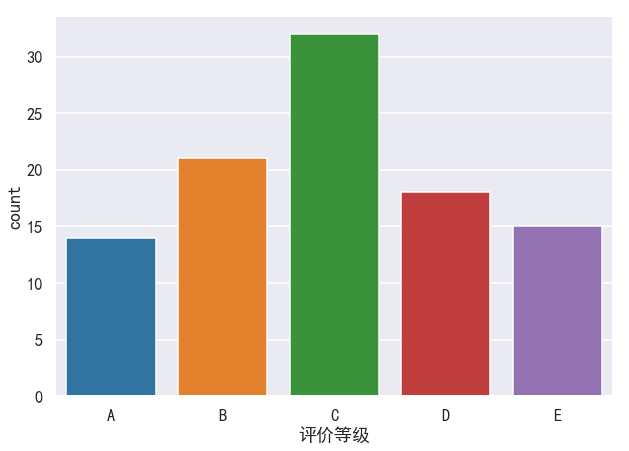

```python
#
fig = plt.figure(figsize=(10,7))
ax = fig.add_subplot(111)
_ = sns.countplot(data=data[['评价等级']],x='评价等级',order=sorted(data['评价等级'].unique().tolist()))
```

### 绘制评价等级的帕累托图

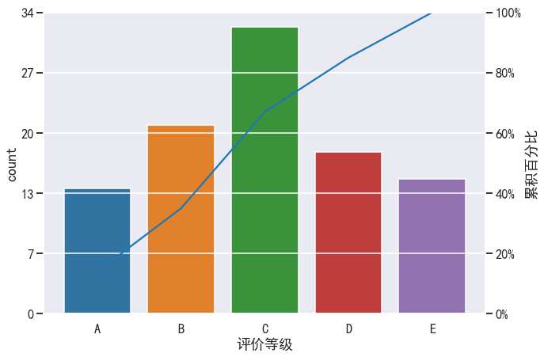

```python
#

fig = plt.figure(figsize=(10,7))
ax = fig.add_subplot(111)
sns.countplot(data=data[['评价等级']],x='评价等级',order=sorted(data['评价等级'].unique().tolist()))
yticks = np.linspace(0, ax.get_ylim()[1], 6, endpoint=True)
yticks_labels = [f'{ytick:.0f}' for ytick in yticks]
ax.set_yticks(yticks)
ax.set_yticklabels(yticks_labels)

ax_2 = ax.twinx()
sns.lineplot(count['评价等级'], count['累积百分比'], markers='o', markersize=10,)
yticks = np.linspace(0, 1, 6, endpoint=True)
yticks_labels = [f'{ytick*100:.0f}%' for ytick in yticks]
ax_2.set_ylim((0, 1))
ax_2.set_yticks(yticks)
_ = ax_2.set_yticklabels(yticks_labels)
```

## 3.2

为了确定灯泡的使用寿命，在一批灯泡中随机抽取100个进行测试，所得结果如下:

[figure not shown]

### 利用计算机对上面的数据进行排序

```python
data = pd.read_excel('../source/《统计学》（第7版）—例题习题数据/（03）第3章  数据的图表展示（7）/（3-2）本章练习题数据/习题3.2.xlsx')
print(sorted(data['使用寿命'].tolist()))
```

```
[651, 658, 661, 664, 665, 666, 668, 671, 673, 674, 676, 677, 679, 681, 681, 682, 683, 683, 683, 684, 685, 685, 685, 688, 688, 689, 689, 690, 690, 691, 691, 691, 691, 692, 692, 692, 693, 693, 694, 694, 695, 695, 696, 696, 696, 697, 697, 698, 698, 698, 698, 699, 699, 700, 700, 701, 701, 702, 702, 703,…
```

### 以组距为10进行等距分组，整理成频数分布表

```python
#
data['分组'] = pd.cut(data['使用寿命'], bins=np.linspace(start=650,stop=750, num=11))
count = data.groupby('分组').count()
count.reset_index(inplace=True)
count.columns = ['分组', '频数']
count['百分比'] = count['频数'].apply(lambda x: x/count['频数'].sum())
count['累积百分比'] = count['百分比'].cumsum()
count
```

|  | 分组 | 频数 | 百分比 | 累积百分比 |
| --- | --- | --- | --- | --- |
| 0 | (650.0, 660.0] | 2 | 0.02 | 0.02 |
| 1 | (660.0, 670.0] | 5 | 0.05 | 0.07 |
| 2 | (670.0, 680.0] | 6 | 0.06 | 0.13 |
| 3 | (680.0, 690.0] | 16 | 0.16 | 0.29 |
| 4 | (690.0, 700.0] | 26 | 0.26 | 0.55 |
| 5 | (700.0, 710.0] | 18 | 0.18 | 0.73 |
| 6 | (710.0, 720.0] | 12 | 0.12 | 0.85 |
| 7 | (720.0, 730.0] | 9 | 0.09 | 0.94 |
| 8 | (730.0, 740.0] | 3 | 0.03 | 0.97 |
| 9 | (740.0, 750.0] | 3 | 0.03 | 1.00 |

### 根据分组数据绘制直方图，说明数据分布的特点

数据呈右偏态

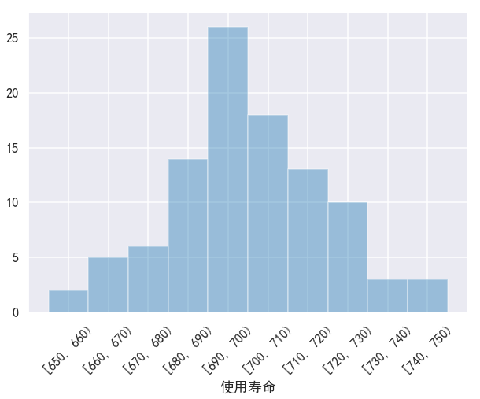

```python
#
fig = plt.figure(figsize=(10,7))
ax = fig.add_subplot(111)
bins = np.linspace(start=650,stop=750, num=11)
sns.distplot(data['使用寿命'], hist=True, bins=bins, kde=False)
ax.set_xticks((bins+5)[:-1])
xtickslabels = [f'[{bins[i]:.0f}, {bins[i+1]:.0f})' for i in range(10)]
_ = ax.set_xticklabels(xtickslabels, rotation=45)
```

### 制作茎叶图，并与直方图做比较

```python
#
data['stem'] = data['使用寿命'].apply(lambda x: x//10)
data['leaf'] = data['使用寿命'].apply(lambda x: x%10)
gp = data.groupby('stem')
print('灯泡使用寿命 Stem-and-leaf Plot\n')
print('{:10s} {:4s} | {:100s}'.format('Frequency', 'stem', 'leaf'))
for stem, df in gp:
    leaves = sorted(df["leaf"].tolist())
    frequency = len(leaves)
    leaves = [str(leaf) for leaf in leaves]
    leaves = "".join(leaves)
    print(f'{frequency:10d} {stem:4d} | {leaves}')
```

```
灯泡使用寿命 Stem-and-leaf Plot

Frequency  stem | leaf
         2   65 | 18
         5   66 | 14568
         6   67 | 134679
        14   68 | 11233345558899
        26   69 | 00111122233445566677888899
        18   70 | 001122345666778889
        13   71 | 0022335677889
        10   72 | 0122567899
         3   73 | 356
         3   74 | 179
```

## 3.3

一种带装饰品用生产线自动装填，每袋重量大约为50克，但由于某些原因，每袋重量不会恰好是50克，随机抽取100袋食品，测得重量数据如下:

[figure not shown]

### 构建这些数据的频数分布表

```python
#
data = pd.read_excel('../source/《统计学》（第7版）—例题习题数据/（03）第3章  数据的图表展示（7）/（3-2）本章练习题数据/习题3.3.xlsx')
bins = np.linspace(39,63,9,endpoint=True)
data['分组'] = pd.cut(data['重量'], bins=bins)
count = data.groupby('分组').count()
count.reset_index(inplace=True)
count.columns = ['分组', '频数']
count['百分比'] = count['频数'].apply(lambda x: x/count['频数'].sum())
count['累积百分比'] = count['百分比'].cumsum()
count
```

|  | 分组 | 频数 | 百分比 | 累积百分比 |
| --- | --- | --- | --- | --- |
| 0 | (39.0, 42.0] | 3 | 0.03 | 0.03 |
| 1 | (42.0, 45.0] | 9 | 0.09 | 0.12 |
| 2 | (45.0, 48.0] | 24 | 0.24 | 0.36 |
| 3 | (48.0, 51.0] | 19 | 0.19 | 0.55 |
| 4 | (51.0, 54.0] | 24 | 0.24 | 0.79 |
| 5 | (54.0, 57.0] | 14 | 0.14 | 0.93 |
| 6 | (57.0, 60.0] | 6 | 0.06 | 0.99 |
| 7 | (60.0, 63.0] | 1 | 0.01 | 1.00 |

### 画出频数的直方图

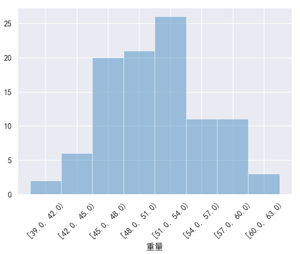

```python
#
fig = plt.figure(figsize=(10,7))
ax = fig.add_subplot(111)
sns.distplot(data['重量'], hist=True, bins=bins, kde=False)
ax.set_xticks((bins+1.5)[:-1])
xtickslabels = [f'[{bins[i]:.1f}, {bins[i+1]:.1f})' for i in range(8)]
_ = ax.set_xticklabels(xtickslabels, rotation=45)
```

### 说明数据分布的特征

数据呈左偏态

## 3.4

给下面数据绘制散点图

[figure not shown]

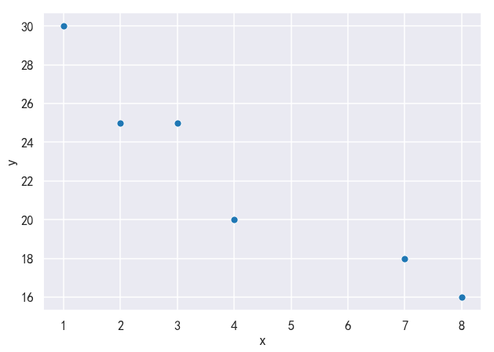

```python
#
data = pd.read_excel('../source/《统计学》（第7版）—例题习题数据/（03）第3章  数据的图表展示（7）/（3-2）本章练习题数据/习题3.4.xlsx')
fig = plt.figure(figsize=(10,7))
ax = fig.add_subplot(111)
_ = sns.scatterplot(data=data, x='x', y='y')
```

## 3.5

甲，乙两个班各有40名学生，期末统计学考试成绩的分布如下:

[figure not shown]

### 根据上面数据，画出两个班考试成绩的对比条形图和环形图

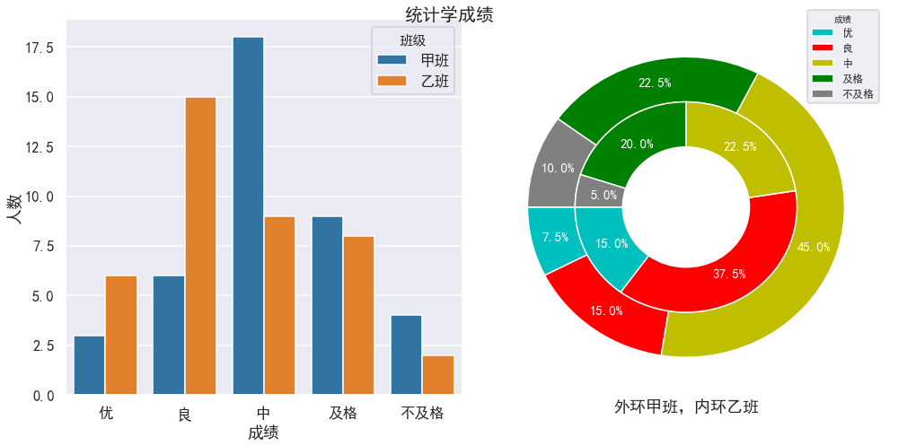

```python
#
data = pd.read_excel('../source/《统计学》（第7版）—例题习题数据/（03）第3章  数据的图表展示（7）/（3-2）本章练习题数据/习题3.5.xlsx', skiprows=1)
data.columns = ['成绩', '甲班', '乙班']
data_jia = data[['成绩', '甲班']].copy()
data_jia['班级'] = '甲班'
data_jia.columns = ['成绩', '人数', '班级']
data_jia['比例'] = data_jia['人数'].apply(lambda x: x/ data_jia['人数'].sum())
data_yi = data[['成绩', '乙班']].copy()
data_yi['班级'] = '乙班'
data_yi.columns = ['成绩', '人数', '班级']
data_yi['比例'] = data_yi['人数'].apply(lambda x: x/ data_yi['人数'].sum())
data = pd.concat([data_jia, data_yi])
data.index = range(data.shape[0])

# 条形图
fig = plt.figure(figsize=(14,7))
ax = fig.add_subplot(121)
_ = sns.barplot(data=data, x='成绩', y='人数', hue='班级')

# 环形图

ax = fig.add_subplot(122)
colors = ['c', 'r', 'y', 'g', 'gray']
# 外环
wedges1, texts1, autotexts1 = plt.pie(data_jia['比例'],
    autopct = '%3.1f%%',
    radius = 1,
    pctdistance = 0.85,
    startangle = 180,
    colors = colors,
    textprops = {'color': 'w'},
    wedgeprops = {'width': 0.3, 'edgecolor': 'w'}
)

# 内环
wedges2, texts2, autotexts2 = plt.pie(data_yi['比例'],
    autopct = '%3.1f%%',
    radius = 0.7,
    pctdistance = 0.75,
    startangle = 180,
    colors = colors,
    textprops = {'color': 'w'},
    wedgeprops = {'width': 0.3, 'edgecolor': 'w'}
)

ax.set_xlabel('外环甲班，内环乙班')
# 图例
plt.legend(wedges1,
          data_jia['成绩'],
          fontsize = 12,
          title = '成绩',
          loc = 'center right',
          bbox_to_anchor = (1.0, 0.9))

# 设置文本样式
plt.setp(autotexts1, size=15, weight='bold')
plt.setp(autotexts2, size=15, weight='bold')
plt.setp(texts1, size=15)

# 标题
plt.suptitle('统计学成绩', fontsize=20)
plt.tight_layout()

plt.show()
```

### 比较两个班的成绩分布的特点

两个班成绩都稍微右偏态，但是乙班看起来更严重，乙班成绩分布得更均匀一些

### 画出雷达图，看看两个班考试成绩的分布是否相似

两个班成绩分布不相似

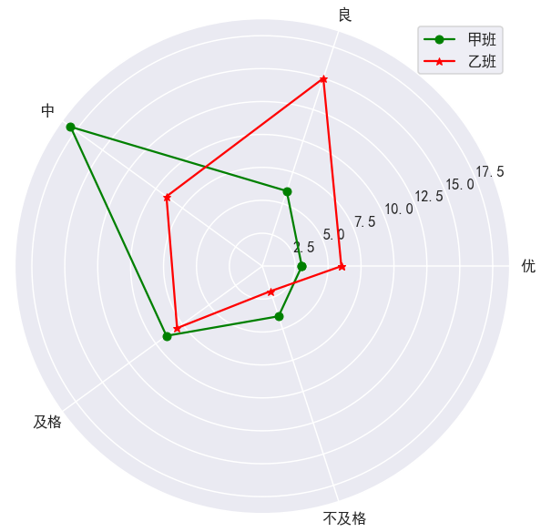

```python
#
angles = np.linspace(0, 2*np.pi, 5, endpoint=False)
fig = plt.figure(figsize=(12,10))
ax = fig.add_subplot(111, polar=True)
plt.plot(list(angles)+[0], data_jia['人数'].tolist() + data_jia['人数'].tolist()[0:1], '-og')
plt.plot(list(angles)+[0], data_yi['人数'].tolist() + data_yi['人数'].tolist()[0:1], '-*r')
plt.legend(['甲班', '乙班'])
_ = plt.thetagrids(angles*180/np.pi,data_jia['成绩'].tolist())
```

## 3.6

1997年我国几个主要程式各月份的平均相对湿度数据如下表所示(单位: %)， 试绘制箱线图，并分析各城市平均相对湿度的分布特征．

[figure not shown]

```python
#
data = pd.read_excel('../source/《统计学》（第7版）—例题习题数据/（03）第3章  数据的图表展示（7）/（3-2）本章练习题数据/习题3.6.xlsx')
data.set_index('月份',inplace=True)
Data = pd.DataFrame()
for city in data.columns:
    df = data[[city]].copy()
    df['城市'] = city
    df.columns = ['湿度', '城市']
    Data = pd.concat([Data, df])
data = Data
data.index = range(data.shape[0])
```

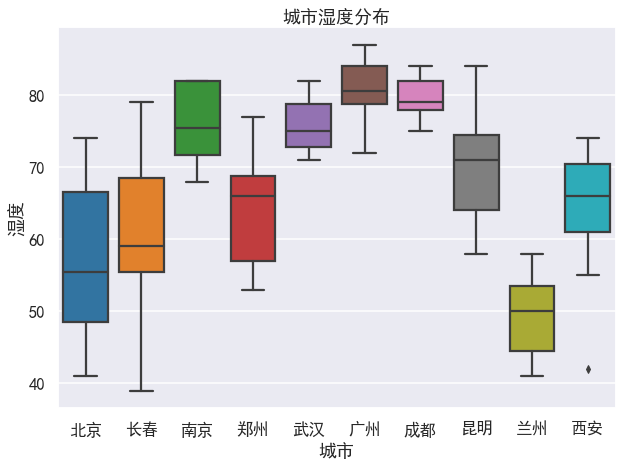

```python
#
fig = plt.figure(figsize=(10,7))
ax = fig.add_subplot(111)
sns.boxplot(data=data, x='城市', y='湿度')
_ = plt.title('城市湿度分布')
```

可以发现，武汉，广州，成都全年都保持一个比较高的湿度，而且变化较小，长春，北京的湿度变化则变化较大，兰州全年的湿度都较小，西安则出现湿度突变的情况

# 补充气泡图的展示

根据例3.9进行画图展示

```python
data = pd.read_excel('../source/《统计学》（第7版）—例题习题数据/（03）第3章  数据的图表展示（7）/（3-1）本章例题数据/例3.9.xlsx')
data
```

|  | 温度 | 降雨量 | 产量 |
| --- | --- | --- | --- |
| 0 | 6 | 25 | 2250 |
| 1 | 8 | 40 | 3450 |
| 2 | 10 | 58 | 4500 |
| 3 | 13 | 68 | 5750 |
| 4 | 14 | 110 | 5800 |
| 5 | 16 | 98 | 7500 |
| 6 | 21 | 120 | 8250 |

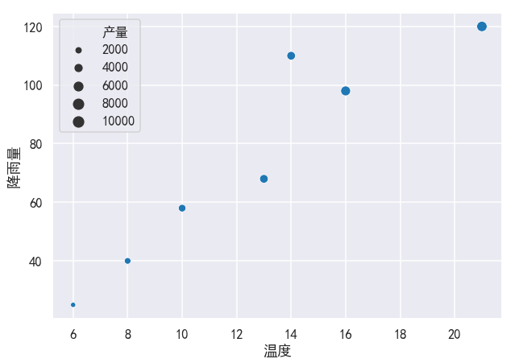

```python
fig = plt.figure(figsize=(10,7))
ax = fig.add_subplot(111)
sns.scatterplot(data=data, x='温度', y='降雨量', size='产量')
```